# SIV Key Exposures

jonasalexandersteiner

2025-10-08

# Logistic regression of key factors in binary PLSR

This report presents summary results and visualizations for a logistic regression model for SIV status in pig herds:

## Husbandry Subset Model

### Model Sample Size

N (Husbandry model used): 125

Top 25 by VIP with exclusion rationale

| variable | VIP | exclusion_due_to_biological_plausibility |
| --- | --- | --- |
| contact_bird_in_stable_TRUE | 3.02 |  |
| ai_airspace_with_other_agegroup_2 | 2.71 | more intensive farming |
| cross_fostering_farrowing_stable_2 | 2.55 |  |
| caretaker_entry_ppe_only_TRUE | 2.01 | more intensive farming |
| drying_farrowing_stable_TRUE | 1.99 |  |
| outside_area_contact_wild_boars_TRUE | 1.85 | more intensive farming |
| ai_airspace_with_other_agegroup_3 | 1.80 | more intensive farming |
| production_type_factor_2 | 1.80 | explained by Weaners_on_farm |
| mode_stable_occupation_gestation_stable_TRUE | 1.77 | more intensive farming |
| fattening_pigs_airspace_with_other_agegroup_4 | 1.54 | more intensive farming |
| cross_fostering_farrowing_stable_3 | 1.51 | explained by cross_fostering_farrowign_stable_2 |
| cleaning_weaner_stable_NA | 1.51 | missingness indicator |
| cleaning_farrowing_stable_TRUE | 1.50 |  |
| bird_nests_TRUE | 1.49 | more intensive farming |
| weaners_airspace_with_other_agegroup_4 | 1.47 | more intensive farming |
| cleaning_quarantine_2 | 1.44 |  |
| canton_factor_Lucerne | 1.37 |  |
| caretaker_type_4 | 1.35 |  |
| Isemination_on_farm_TRUE | 1.31 |  |
| Weaners_on_farm_TRUE | 1.31 | explained by Weaners_on_farm |
| farrowing_airspace_with_other_agegroup_NA | 1.25 |  |
| passing_through_other_age_group_TRUE | 1.24 | missingness indicator |
| caretaker_ppe_washing_interval_TRUE | 1.23 | more intensive farming |
| seperation_quarantine_area_2 | 1.23 | explained by seperation_quarantine_area_3 |
| drying_weaner_stable_TRUE | 1.21 |  |

### Model Coefficients

**Logistic regression coefficients, standard errors, and z-values. Model includes final 4 predictors plus the confounder `symptomatic_report_TRUE`.**

Coefficients (Husbandry Model)

| Predictor | Estimate | Std. Error | z value |
| --- | --- | --- | --- |
| (Intercept) | -0.625 | 0.507 | -1.231 |
| contact_bird_in_stable_TRUE | 1.077 | 0.400 | 2.693 |
| cross_fostering_farrowing_stable_2 | -0.769 | 0.466 | -1.651 |
| drying_farrowing_stable_TRUE | -0.848 | 0.652 | -1.301 |
| cleaning_farrowing_stable_TRUE | 0.635 | 0.766 | 0.829 |
| symptomatic_report_TRUE | 0.558 | 0.556 | 1.002 |

### Odds Ratios and Confidence Intervals

Odds Ratios & 95% CI (Husbandry Model)

| Predictor | Odds Ratio | 2.5 % | 97.5 % |
| --- | --- | --- | --- |
| (Intercept) | 0.535 | 0.191 | 1.427 |
| contact_bird_in_stable_TRUE | 2.937 | 1.352 | 6.534 |
| cross_fostering_farrowing_stable_2 | 0.463 | 0.182 | 1.144 |
| drying_farrowing_stable_TRUE | 0.428 | 0.115 | 1.537 |
| cleaning_farrowing_stable_TRUE | 1.887 | 0.432 | 8.998 |
| symptomatic_report_TRUE | 1.746 | 0.587 | 5.293 |

### Diagnostics Overview

- **Pseudo-R² (McFadden):** 0.101 — > 0.2 = reasonable; lower = weak fit.  
  Model fit is weak.
- **AUC (ROC Curve):** 0.71 — > 0.7 = acceptable, > 0.8 = good.  
  Discrimination is acceptable.

### Multicollinearity

**Variance Inflation Factor (VIF) for each predictor. VIF > 5 signals multicollinearity.**

Variance Inflation Factor (Husbandry Model)

| Predictor | VIF |
| --- | --- |
| contact_bird_in_stable_TRUE | 1.02 |
| cross_fostering_farrowing_stable_2 | 1.27 |
| drying_farrowing_stable_TRUE | 2.52 |
| cleaning_farrowing_stable_TRUE | 3.06 |
| symptomatic_report_TRUE | 1.35 |

### Top 5 Influential Observations

**Cook’s Distance for the top 5 most influential points; high values may indicate outliers.**

Top 5 Cook’s Distance Values (Husbandry Model)

| Observation | Cook_Distance |
| --- | --- |
| 59 | 0.051 |
| 66 | 0.040 |
| 3 | 0.036 |
| 114 | 0.033 |
| 120 | 0.028 |

### Visualizations

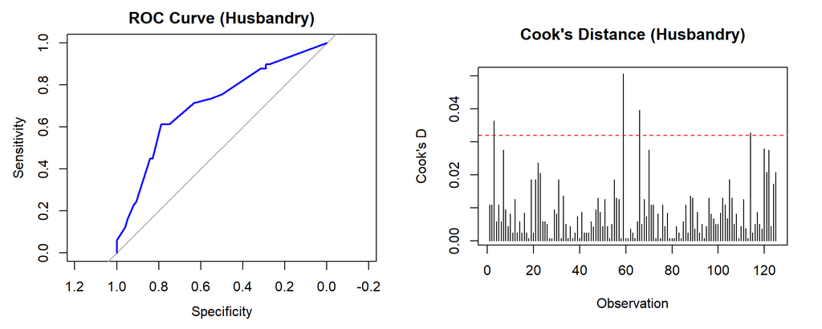

### Calibration

**Calibration of model predictions was assessed by the Hosmer-Lemeshow test and a calibration plot.**

**Hosmer-Lemeshow Test:**  
Chi-squared = NaN , df = 4 , p-value = NaN  
A p-value > 0.05 suggests good calibration.

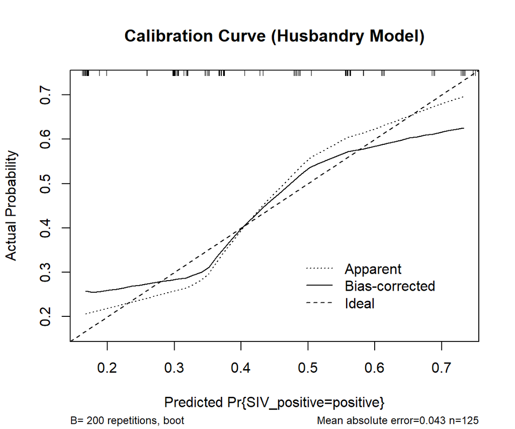

n=125 Mean absolute error=0.043 Mean squared error=0.00292 0.9 Quantile of absolute error=0.091

## Interpretation Notes

- **Exploratory Analysis:** No p-values or statistical significance are interpreted for selection, but all effect sizes and CIs are transparently reported.
- **Biological plausibility exclusion:** See the ‘exclusion_due_to_biological_plausibility’ column in tables for rationale for exclusion.
- **Confounding:** The model is adjusted for `symptomatic_report_TRUE` as a confounder.
- **Model Fit:** Consider pseudo-R² and AUC for overall model quality.
- **Calibration:** Hosmer-Lemeshow and calibration curve should be checked for model reliability.
- **Multicollinearity:** High VIFs may require model simplification.
- **Influential Points:** Consider sensitivity analysis excluding high Cook’s D observations.